# Geostatistical Model - FoDP (Final)

[figure not shown]

### This Jupyter Notebook highlights the "Step-by-Step" analytic procedures of a data science model to examine relationships between vegetation and wildlife at Seattle's Discovery Park. The sample data used in this notebook does not accurately reflect statistical correlations in Discovery Park's ecosystem because the Friends of Discovery Park is still collecting data to enable representative findings. This notebook should be considered a framework that will only produce interpretive findings once the first phase of data collection is complete. Details regaring the background and rationale of this analysis are presented in "Friend of Discovery Park Virtual Management Platform (VMP) - Phase 2" by Hall, Lewis, and Lin (2019), which is available for download at: https://depts.washington.edu/mgis/capstone/capstone.html

[figure not shown]

### The following libraries were used in this analysis: 1. [*arcpy*](https://pro.arcgis.com/en/pro-app/arcpy/get-started/a-quick-tour-of-arcpy.htm) *(must have license through ArcGIS, not open source)* 2. [*pandas*](https://pandas.pydata.org/) 3. [*numpy*](https://www.numpy.org/) 4. [*scikit-learn*](https://scikit-learn.org/stable/documentation.html) 5. [*os*](https://docs.python.org/3/library/os.html) 6. [*matplotlib*](https://matplotlib.org/) *(used to render findings, not to generate results)*

### **The following books were used to guide us through analayses:** 1. [*PYTHON Scripting for ArcGIS (by Paul A. Zandergen)*](https://esripress.esri.com/display/index.cfm?fuseaction=display&websiteID=276&moduleID=0) 2. [*Hands-On Machine Learning with Scikit-Learn & TensorFlow (by Aurélien Géron)*](http://shop.oreilly.com/product/0636920052289.do)

Note(s):  
Some Python3 libraries used in analyses may not be compatitble with versions of libraries installed on other PCs. Please read output log to determine if pip installtion of additional libraries are needed to replicate this framework on other computers.  
The easiest way to use the Jupyter-Notebook with the arcpy library is to use the pre-installed Jupyter-Notebook that comes with ArcGIS Desktop (i.e., Start button --> ArcGIS Folder--> Jupyter Notebook). If one prefers to operate Jupyter-Notebook from a particular directory one must navigate to:  
1. Start button --> ArcGIS Folder--> Python Command Prompt  
2. Change directory where you want notebook located (e.g., "cd C:\Users\username\Documents\GEOG)  
3. Type "jupyer notebook".  
If one wants to pip install a library not preloaded with ArcGIS Desktop, one must navigate to:  
1. Start button --> ArcGIS Folder--> (and right click on) Python Command Prompt --> select "open file location"  
2. Right-click on "Python Command Prompt" and select "Run as Administrator" (note: you will not be able to install external libraries if you do not have administrative priveleges. As such, be very mindful of the libraries you install because not all libraries are useful and warrant installation. Only install reputable libraries)  
3. Follow pip installation instructions in the library's documentation  
4. change directory, if desired, and open Jupyter-Notebook.

```python
import arcpy
import pandas as pd
import numpy as np
import matplotlib.pyplot as plt
import matplotlib as matplotlib
import sklearn as sklearn
from matplotlib.ticker import FuncFormatter
from sklearn.model_selection import train_test_split
from sklearn.model_selection import cross_val_score, GridSearchCV
from sklearn.ensemble import RandomForestRegressor
from sklearn.preprocessing import MinMaxScaler
import os
import getpass
from arcgis.gis import GIS
import sys
from arcgis.mapping import WebMap
from arcgis.features import SpatialDataFrame
pd.set_option('display.max_columns', None)
pd.set_option('display.max_rows', None)
pd.set_option('display.max_colwidth', -1)
direct="C:/Users/lewis/Documents/GEOG 569/"
```

### To fully replicate analyses highlighted in this notebook, you must have access to the Firends of Discovery Park AGOL account. Otherwise, you will not be able to live demo analyses.

```python
u = getpass.getpass(prompt='Enter username')
p = getpass.getpass(prompt='Enter password')
gis = GIS('https://fodp.maps.arcgis.com/',u, p)
```

```
Enter username········
Enter password········
```

### Now we will import data used in this analytic demo. To do this, we will search for the web feature layer in FoDP's AGOL's contents section. Thereafter, we will import the attribute tables of the feature classes using the ArcGIS Python API to convert the attribute table as a pandas dataframe. Some of the really large tables and feature classes will be imported using the "read_csv" function because it would take a long time importing from the AGOL cloud.

```python
search_result = gis.content.search(query="Input Data Used for Geospatial Analysis v2")
search_result
```

```
[<Item title:"Input Data Used for Geospatial Analysis v2" type:Feature Layer Collection owner:FoDP1974>,
 <Item title:"Input Data Used for Geospatial Analysis v2" type:Service Definition owner:FoDP1974>]
```

```python
#The required data is a "Feature Layer Collection" so it's the second option (i.e., indexed at 0)
dataSource = search_result[0].layers
for lyr in dataSource:
    print(lyr.properties.name)
```

```
BirdData_Project
Scenarios
DataGrid_500sqft_hexbins_polygons
DataGrid_500sqft_hexbins_Vegatation
DataGrid_500sqft_hexbins_Key
```

```python
#Lets import the bird data
birds = dataSource[0].query().sdf
birds.head(2)
```

|  | Count_ | ID | Latitude | Longitude | Loop | Month | Month_No | OBJECTID | Precipitation | SHAPE | Site | Species | Station | Survey_Date | Weather | Year |
| --- | --- | --- | --- | --- | --- | --- | --- | --- | --- | --- | --- | --- | --- | --- | --- | --- |
| 0 | 1 | 2001 | 242770.495227 | 1.250581e+06 | South Meadow | April | 4 | 1 | None | {"x": 1250581.3573491424, "y": 242770.49522730708, "spatialReference": {"wkid": 102748, "latestWkid": 2285}} | Discovery Park | Ruby-crowned Kinglet | 9 | 2016-04-02 | Fog | 2016 |
| 1 | 4 | 1 | 245355.679689 | 1.248474e+06 | South Beach Trail | July | 7 | 2 | None | {"x": 1248473.8956848085, "y": 245355.67968948185, "spatialReference": {"wkid": 102748, "latestWkid": 2285}} | Discovery Park | American Goldfinch | 1 | 2016-07-12 | Cloudy | 2016 |

```python
#now lets create and display data dictionary for the bird data
birdsDictionary = birds.dtypes.to_frame('dtypes').reset_index()
birdsDictionary.columns = ['Column','Data Type']
column = [
birdsDictionary['Column'] == 'Count_',
birdsDictionary['Column'] == 'ID',
birdsDictionary['Column'] == 'Latitude',
birdsDictionary['Column'] == 'Longitude',
birdsDictionary['Column'] == 'Loop',
birdsDictionary['Column'] == 'Month',
birdsDictionary['Column'] == 'Month_No',
birdsDictionary['Column'] == 'OBJECTID',
birdsDictionary['Column'] == 'Precipitation',
birdsDictionary['Column'] == 'SHAPE',
birdsDictionary['Column'] == 'Site',
birdsDictionary['Column'] == 'Species',
birdsDictionary['Column'] == 'Station',
birdsDictionary['Column'] == 'Survey_Date',
birdsDictionary['Column'] == 'Weather',
birdsDictionary['Column'] == 'Year'
]
descriptions = [
'The count of birds witnessed',
'Indexed unique identifier for bird data collection event',
'Latitude coordinate (feet) where collection occurred',
'Longitude coordinate (feet) where collection occurred',
'Park specific descriptive location',
'Descriptive month',
'Month of event in integer format (1-12)',
'Default index for feature clases created by ArcGIS',
'Descripiton of whether precipitation took place',
'Geometry object of feature class',
'Park where bird siting took place',
'Descriptive bird species',
'Station number where bird sighting took place',
'Date when bird sighting took place (YYYY-MM-DD)',
'Descripiton of weather on the day of bird sighting',
'Year when bird sighting took place (YYYY)'
]
birdsDictionary['Description'] = np.select(column,descriptions, default='error')
birdsDictionary
```

|  | Column | Data Type | Description |
| --- | --- | --- | --- |
| 0 | Count_ | int64 | The count of birds witnessed |
| 1 | ID | int64 | Indexed unique identifier for bird data collection event |
| 2 | Latitude | float64 | Latitude coordinate (feet) where collection occurred |
| 3 | Longitude | float64 | Longitude coordinate (feet) where collection occurred |
| 4 | Loop | object | Park specific descriptive location |
| 5 | Month | object | Descriptive month |
| 6 | Month_No | int64 | Month of event in integer format (1-12) |
| 7 | OBJECTID | int64 | Default index for feature clases created by ArcGIS |
| 8 | Precipitation | object | Descripiton of whether precipitation took place |
| 9 | SHAPE | geometry | Geometry object of feature class |
| 10 | Site | object | Park where bird siting took place |
| 11 | Species | object | Descriptive bird species |
| 12 | Station | int64 | Station number where bird sighting took place |
| 13 | Survey_Date | datetime64[ns] | Date when bird sighting took place (YYYY-MM-DD) |
| 14 | Weather | object | Descripiton of weather on the day of bird sighting |
| 15 | Year | int64 | Year when bird sighting took place (YYYY) |

```python
#now lets import the polygons with our simulated scenarios to output bird counts when we modify land type
Scenarios = dataSource[1].query().sdf
Scenarios.head()
```

|  | Acres | OBJECTID | SHAPE | Scenario | SceneDesc | Shape__Area | Shape__Length |
| --- | --- | --- | --- | --- | --- | --- | --- |
| 0 | 1.714403 | 2 | {"rings": [[[1248550.28595197, 244268.967952147], [1248866.22659306, 244138.148988053], [1248876.09993289, 243985.115173399], [1248515.72991872, 243985.115173399], [1248550.28595197, 244268.967952147]… | 1 | SouthWest Bird Alley Area | 74675.005646 | 1141.623800 |
| 1 | 2.030819 | 3 | {"rings": [[[1248019.60459864, 244308.460655317], [1248479.9350428, 244318.225399554], [1248478.2342588, 244061.324338555], [1248125.7408693, 244123.338978305], [1248019.60459864, 244308.460655317]]],… | 2 | Southern SouthBluff Forrest Trail | 88457.468323 | 1288.636852 |
| 2 | 5.580866 | 4 | {"rings": [[[1249251.27930065, 244199.85588564], [1249858.47756131, 244209.729225472], [1249878.22391289, 243743.223268732], [1249251.27930065, 243876.510403723], [1249251.27930065, 244199.85588564]]]… | 3 | Bird Alley and Sludge Meadow | 243088.137878 | 2038.504016 |
| 3 | 2.160569 | 5 | {"rings": [[[1247768.61067806, 245224.19471623], [1248069.43323913, 244880.94868356], [1248007.72601347, 244688.113767385], [1247637.48298755, 245062.213412896], [1247768.61067806, 245224.19471623]]],… | 4 | Bluff Forest Trails | 94108.562103 | 1393.620910 |
| 4 | 6.552782 | 6 | {"rings": [[[1249334.67053805, 243002.01412122], [1250202.42733271, 243068.301062137], [1250176.45494372, 242705.222391978], [1249304.54034898, 242706.735840395], [1249334.67053805, 243002.01412122]]]… | 5 | South Bluff and Meadow | 285422.697968 | 2403.018790 |

```python
#data dictionary for the polygon scenarios
ScenariosDictionary = Scenarios.dtypes.to_frame('dtypes').reset_index()
ScenariosDictionary.columns = ['Column','Data Type']
column = [
ScenariosDictionary['Column'] == 'Acres',
ScenariosDictionary['Column'] == 'OBJECTID',
ScenariosDictionary['Column'] == 'SHAPE',
ScenariosDictionary['Column'] == 'Scenario',
ScenariosDictionary['Column'] == 'SceneDesc',
ScenariosDictionary['Column'] == 'Shape__Area',
ScenariosDictionary['Column'] == 'Shape__Length'
]
descriptions = [
'The acreage of the area simulated for change in landcover/vegetation status',
'Default index for feature clases created by ArcGIS',
'Geometry object of feature class',
'Nominal indicator (1-5) identifying simulated change in landcover/vegetation status',
'Descriptive summary where change in landcover/vegetation status will take place',
'Area (in meters) of the polygon simulated for change in landcover/vegetation status',
'Length of perimeter of polygon simulated for change in landcover/vegetation status'
]
ScenariosDictionary['Description'] = np.select(column,descriptions, default='error')
ScenariosDictionary
```

|  | Column | Data Type | Description |
| --- | --- | --- | --- |
| 0 | Acres | float64 | The acreage of the area simulated for change in landcover/vegetation status |
| 1 | OBJECTID | int64 | Default index for feature clases created by ArcGIS |
| 2 | SHAPE | geometry | Geometry object of feature class |
| 3 | Scenario | int64 | Nominal indicator (1-5) identifying simulated change in landcover/vegetation status |
| 4 | SceneDesc | object | Descriptive summary where change in landcover/vegetation status will take place |
| 5 | Shape__Area | float64 | Area (in meters) of the polygon simulated for change in landcover/vegetation status |
| 6 | Shape__Length | float64 | Length of perimeter of polygon simulated for change in landcover/vegetation status |

```python
#importing the polygon hexbins
hexbins_polygons = dataSource[2].query().sdf
hexbins_polygons.head(2)
```

|  | Acres | Agriculture | GRID_ID | LC | OBJECTID | Riparian | SHAPE | Shape__Area | Shape__Length | Urban | zoneMGT |
| --- | --- | --- | --- | --- | --- | --- | --- | --- | --- | --- | --- |
| 0 | 0.011479 | 0 | LE-122 | Deciduous Forest | 1 | 0 | {"rings": [[[1252054.12900989, 245971.60627915], [1252040.25666231, 245971.60627915], [1252033.32032447, 245983.62003465], [1252040.25666231, 245995.634118229], [1252054.12900989, 245995.634118229], [… | 499.987701 | 83.234809 | 0 | North Forest |
| 1 | 0.011479 | 0 | LO-254 | Grassland/ Herbaceous | 2 | 0 | {"rings": [[[1252262.2188168, 242799.895759061], [1252248.34614114, 242799.895759061], [1252241.4098033, 242811.90984264], [1252248.34614114, 242823.923926219], [1252262.2188168, 242823.923926219], [1… | 500.002472 | 83.236033 | 0 | South Parking Area |

```python
#data dictionary for the polygon hexbins
hexPolyDictionary = hexbins_polygons.dtypes.to_frame('dtypes').reset_index()
hexPolyDictionary.columns = ['Column','Data Type']
column = [
hexPolyDictionary['Column'] == 'Acres',
hexPolyDictionary['Column'] == 'Agriculture',
hexPolyDictionary['Column'] == 'GRID_ID',
hexPolyDictionary['Column'] == 'LC',
hexPolyDictionary['Column'] == 'OBJECTID',
hexPolyDictionary['Column'] == 'Riparian',
hexPolyDictionary['Column'] == 'SHAPE',
hexPolyDictionary['Column'] == 'Shape__Area',
hexPolyDictionary['Column'] == 'Shape__Length',
hexPolyDictionary['Column'] == 'Urban',
hexPolyDictionary['Column'] == 'zoneMGT'
]
descriptions = [
'The acreage of the hexbin',
'Indicator (0-1) whether the landcover in hexbin is agrarian',
'Indexed unique identifier for hexbin',
'Landcover type',
'Default index for feature clases created by ArcGIS',
'Indicator (0-1) whether the landcover in hexbin is riparian',
'Geometry object of feature class',
'Area (in meters) of the hexbin',
'Length of perimeter of hexbin',
'Indicator (0-1) whether the landcover in hexbin is urban',
'Description of zone area within Discover Park'
]
hexPolyDictionary['Description'] = np.select(column,descriptions, default='error')
hexPolyDictionary
```

|  | Column | Data Type | Description |
| --- | --- | --- | --- |
| 0 | Acres | float64 | The acreage of the hexbin |
| 1 | Agriculture | int64 | Indicator (0-1) whether the landcover in hexbin is agrarian |
| 2 | GRID_ID | object | Indexed unique identifier for hexbin |
| 3 | LC | object | Landcover type |
| 4 | OBJECTID | int64 | Default index for feature clases created by ArcGIS |
| 5 | Riparian | int64 | Indicator (0-1) whether the landcover in hexbin is riparian |
| 6 | SHAPE | geometry | Geometry object of feature class |
| 7 | Shape__Area | float64 | Area (in meters) of the hexbin |
| 8 | Shape__Length | float64 | Length of perimeter of hexbin |
| 9 | Urban | int64 | Indicator (0-1) whether the landcover in hexbin is urban |
| 10 | zoneMGT | object | Description of zone area within Discover Park |

```python
#Importing the point data representing vegetation at
#Discovery Park aggregated to the centroids of hexbins
hexbins_pt_veg = dataSource[3].query().sdf
hexbins_pt_veg.head(2)
```

|  | Acres | CommonDom | GRID_ID | Latitude | Longitude | OBJECTID | SHAPE |
| --- | --- | --- | --- | --- | --- | --- | --- |
| 0 | 0.011479 | Red Alder | LE-122 | 245983.620035 | 1.252047e+06 | 1 | {"x": 1252047.1930001378, "y": 245983.62003464997, "spatialReference": {"wkid": 102748, "latestWkid": 2285}} |
| 1 | 0.011479 | Himalayan Blackberry | LO-254 | 242811.909843 | 1.252255e+06 | 2 | {"x": 1252255.2824789733, "y": 242811.90984264016, "spatialReference": {"wkid": 102748, "latestWkid": 2285}} |

```python
#data dictionary for the vegatation data
hexVegDictionary = hexbins_pt_veg.dtypes.to_frame('dtypes').reset_index()
hexVegDictionary.columns = ['Column','Data Type']
column = [
hexVegDictionary['Column'] == 'Acres',
hexVegDictionary['Column'] == 'CommonDom',
hexVegDictionary['Column'] == 'GRID_ID',
hexVegDictionary['Column'] == 'Latitude',
hexVegDictionary['Column'] == 'Longitude',
hexVegDictionary['Column'] == 'OBJECTID',
hexVegDictionary['Column'] == 'SHAPE'
]
descriptions = [
'The acreage of the hexbin',
'Common name of the dominant vegetation species within hexbin',
'Indexed unique identifier for hexbin',
'Latitude coordinate (feet) for hexbin centroid',
'Longitude coordinate (feet) for hexbin centroid',
'Default index for feature clases created by ArcGIS',
'Geometry object of feature class'
]
hexVegDictionary['Description'] = np.select(column,descriptions, default='error')
hexVegDictionary
```

|  | Column | Data Type | Description |
| --- | --- | --- | --- |
| 0 | Acres | float64 | The acreage of the hexbin |
| 1 | CommonDom | object | Common name of the dominant vegetation species within hexbin |
| 2 | GRID_ID | object | Indexed unique identifier for hexbin |
| 3 | Latitude | float64 | Latitude coordinate (feet) for hexbin centroid |
| 4 | Longitude | float64 | Longitude coordinate (feet) for hexbin centroid |
| 5 | OBJECTID | int64 | Default index for feature clases created by ArcGIS |
| 6 | SHAPE | geometry | Geometry object of feature class |

```python
#Importing the point data representing landcover at
#Discovery Park aggregated to the centroids of hexbins
key = dataSource[4].query().sdf
key.head(2)
```

|  | Acres | Agriculture | GRID_ID | LC | Latitude | Longitude | OBJECTID | Riparian | SHAPE | Urban | zoneMGT |
| --- | --- | --- | --- | --- | --- | --- | --- | --- | --- | --- | --- |
| 0 | 0.007986 | 0 | IS-152 | No Data | 245264.823900 | 1.250718e+06 | 1 | 0 | {"x": 1250718.0224301368, "y": 245264.82390005887, "spatialReference": {"wkid": 102748, "latestWkid": 2285}} | 0 | No Zone |
| 1 | 0.011479 | 0 | NE-226 | Grassland/ Herbaceous | 243484.696883 | 1.253129e+06 | 2 | 0 | {"x": 1253129.2584213018, "y": 243484.69688288867, "spatialReference": {"wkid": 102748, "latestWkid": 2285}} | 0 | Visitor Center |

```python
#data dictionary for the polygon hexbins
keyDictionary = key.dtypes.to_frame('dtypes').reset_index()
keyDictionary.columns = ['Column','Data Type']
column = [
keyDictionary['Column'] == 'Acres',
keyDictionary['Column'] == 'Agriculture',
keyDictionary['Column'] == 'GRID_ID',
keyDictionary['Column'] == 'LC',
keyDictionary['Column'] == 'Latitude',
keyDictionary['Column'] == 'Longitude',
keyDictionary['Column'] == 'OBJECTID',
keyDictionary['Column'] == 'Riparian',
keyDictionary['Column'] == 'SHAPE',
keyDictionary['Column'] == 'Urban',
keyDictionary['Column'] == 'zoneMGT'
]
descriptions = [
'The acreage of the hexbin',
'Indicator (0-1) whether the landcover in hexbin is agrarian',
'Indexed unique identifier for hexbin',
'Landcover type',
'Latitude coordinate (feet) for hexbin centroid',
'Longitude coordinate (feet) for hexbin centroid',
'Default index for feature clases created by ArcGIS',
'Indicator (0-1) whether the landcover in hexbin is riparian',
'Geometry object of feature class',
'Indicator (0-1) whether the landcover in hexbin is urban',
'Description of zone area within Discover Park'
]
keyDictionary['Description'] = np.select(column,descriptions, default='error')
keyDictionary
```

|  | Column | Data Type | Description |
| --- | --- | --- | --- |
| 0 | Acres | float64 | The acreage of the hexbin |
| 1 | Agriculture | int64 | Indicator (0-1) whether the landcover in hexbin is agrarian |
| 2 | GRID_ID | object | Indexed unique identifier for hexbin |
| 3 | LC | object | Landcover type |
| 4 | Latitude | float64 | Latitude coordinate (feet) for hexbin centroid |
| 5 | Longitude | float64 | Longitude coordinate (feet) for hexbin centroid |
| 6 | OBJECTID | int64 | Default index for feature clases created by ArcGIS |
| 7 | Riparian | int64 | Indicator (0-1) whether the landcover in hexbin is riparian |
| 8 | SHAPE | geometry | Geometry object of feature class |
| 9 | Urban | int64 | Indicator (0-1) whether the landcover in hexbin is urban |
| 10 | zoneMGT | object | Description of zone area within Discover Park |

#### Now were going to input the scenario based data that we will try to predict bird counts based on vegetation changes.

```python
search_result = gis.content.search(query="ScenariosFeature_pts")
search_result
#The required data is a "Feature Layer Collection" so it's the only option (i.e., indexed at 0)
dataSource = search_result[0].layers
for lyr in dataSource:
    print(lyr.properties.name)
```

```
ScenariosFeature_pts
```

```python
#Importing the point data representing landcover at
#Discovery Park aggregated to the centroids of hexbins
scene = dataSource[0].query().sdf
scene.head()
```

|  | Acres | Agricultur | FID | GRID_ID | LC | Latitude | Longitude | Riparian | SHAPE | Scenario | Urban | modified | zoneMGT |
| --- | --- | --- | --- | --- | --- | --- | --- | --- | --- | --- | --- | --- | --- |
| 0 | 0.011479 | 0 | 1 | GG-168 | Barren - Gravel Dirt | 244878.327298 | 1.249384e+06 | 0 | {"x": -13627760.118629899, "y": 6050521.887328582, "spatialReference": {"wkid": 102100, "latestWkid": 3857}} | 0 | 0 | 0 | No Zone |
| 1 | 0.011479 | 0 | 2 | HN-30 | Barren - Gravel Dirt | 248206.220248 | 1.250070e+06 | 0 | {"x": -13627480.932671629, "y": 6052036.011179986, "spatialReference": {"wkid": 102100, "latestWkid": 3857}} | 0 | 0 | 0 | No Zone |
| 2 | 0.011479 | 0 | 3 | GC-158 | Barren - Gravel Dirt | 245118.608313 | 1.249300e+06 | 0 | {"x": -13627799.949174667, "y": 6050629.96077156, "spatialReference": {"wkid": 102100, "latestWkid": 3857}} | 0 | 0 | 0 | No Zone |
| 3 | 0.011479 | 0 | 4 | HN-161 | Barren - Gravel Dirt | 245058.537895 | 1.250070e+06 | 0 | {"x": -13627451.659931723, "y": 6050609.935733902, "spatialReference": {"wkid": 102100, "latestWkid": 3857}} | 0 | 0 | 0 | Utah Wetlands |
| 4 | 0.011479 | 0 | 5 | FR-165 | Barren - Gravel Dirt | 244962.425555 | 1.249072e+06 | 0 | {"x": -13627901.872535856, "y": 6050557.0676305145, "spatialReference": {"wkid": 102100, "latestWkid": 3857}} | 0 | 0 | 0 | No Zone |

```python
#data dictionary for the polygon hexbins
sceneDictionary = scene.dtypes.to_frame('dtypes').reset_index()
sceneDictionary.columns = ['Column','Data Type']
column = [
sceneDictionary['Column'] == 'Acres',
sceneDictionary['Column'] == 'Agricultur',
sceneDictionary['Column'] == 'FID',
sceneDictionary['Column'] == 'GRID_ID',
sceneDictionary['Column'] == 'LC',
sceneDictionary['Column'] == 'Latitude',
sceneDictionary['Column'] == 'Longitude',
sceneDictionary['Column'] == 'Riparian',
sceneDictionary['Column'] == 'SHAPE',
sceneDictionary['Column'] == 'Scenario',
sceneDictionary['Column'] == 'Urban',
sceneDictionary['Column'] == 'modified',
sceneDictionary['Column'] == 'zoneMGT'
]
descriptions = [
'The acreage of the hexbin',
'Indicator (0-1) whether the landcover in hexbin is agrarian',
'Feature class index created by ArcGIS',
'Indexed unique identifier for hexbin',
'Landcover type',
'Latitude coordinate (feet) for hexbin centroid',
'Longitude coordinate (feet) for hexbin centroid',
'Indicator (0-1) whether the landcover in hexbin is riparian',
'Geometry object of feature class',
'Identifier (0-5) of the scenario for landcover manipulations',
'Indicator (0-1) whether the landcover in hexbin is urban',
'Indicator (0-1) whether the landcover in hexbin is different from original',
'Description of zone area within Discover Park'
]
sceneDictionary['Description'] = np.select(column,descriptions, default='error')
sceneDictionary
```

|  | Column | Data Type | Description |
| --- | --- | --- | --- |
| 0 | Acres | float64 | The acreage of the hexbin |
| 1 | Agricultur | int64 | Indicator (0-1) whether the landcover in hexbin is agrarian |
| 2 | FID | int64 | Feature class index created by ArcGIS |
| 3 | GRID_ID | object | Indexed unique identifier for hexbin |
| 4 | LC | object | Landcover type |
| 5 | Latitude | float64 | Latitude coordinate (feet) for hexbin centroid |
| 6 | Longitude | float64 | Longitude coordinate (feet) for hexbin centroid |
| 7 | Riparian | int64 | Indicator (0-1) whether the landcover in hexbin is riparian |
| 8 | SHAPE | geometry | Geometry object of feature class |
| 9 | Scenario | int64 | Identifier (0-5) of the scenario for landcover manipulations |
| 10 | Urban | int64 | Indicator (0-1) whether the landcover in hexbin is urban |
| 11 | modified | int64 | Indicator (0-1) whether the landcover in hexbin is different from original |
| 12 | zoneMGT | object | Description of zone area within Discover Park |

### This table highlights a few attributes of interest with respect to our framework. First, we have landcover and hexbin grid identifiers (take note that some attributes are null). We also have columns representing the number of various species of birds seen in 2016 at various points in Discovery Park. We transformed this attribute by summing the number of birds within a 700 feet radious of each hexbin. Though our selected buffer distance requires future research, we believed that this approach is ideal because birds are fairly mobile animals, suggesting that standardizing the measure using a "neighborhood" approach is better than accepting a one-time snapshot as "the truth." We also spatially joined the categroization (1=yes, 0=no) of various vegetative species, as well as the Mangement Zone of the hexbin.

```python
#pandas will not allow cross joins on columns
#from different dataframes with same name
key2 = key[['GRID_ID','Latitude','Longitude']]
birds2 = birds[['Species','Count_','Latitude','Longitude']]
birds2['Latitude2']=birds2['Latitude']
birds2['Longitude2']=birds2['Longitude']
del birds2['Latitude']
del birds2['Longitude']

#Lets do a cross join between the birds and hexbins,
#but only keep the rows where bird sightings
#are within 700 feet of a hexbin
test=key2.assign(foo=1).merge(birds2.assign(foo=1)).drop('foo', 1)
test['dist'] = np.sqrt(((test['Latitude']-test['Latitude2']).pow(2))+((test['Longitude']-test['Longitude2']).pow(2)))
test = test[test['dist']<=700]
test.reset_index(inplace=True)
del test['index']

#Sum bird counts within each species at each GRID_ID
birdSum = test.groupby(['GRID_ID','Species'])['Count_'].sum().reset_index()

#now lets pivot the bird Species into separate columns
birdPivot = pd.pivot_table(birdSum,index=['GRID_ID'],columns='Species',values='Count_')
birdPivot.reset_index(inplace=True)

#lets fill the nulls with zeros
birdPivot.fillna(0, inplace=True)
birdPivot.head()
```

| Species | GRID_ID | Accipiter sp. | American Coot | American Crow | American Goldfinch | American Pipit | American Robin | American Wigeon | American x Eurasian Wigeon | Anna's Hummingbird | Bald Eagle | Band-tailed Pigeon | Barn Swallow | Barred Owl | Barrow's Goldeneye | Belted Kingfisher | Bewick's Wren | Black-capped Chickadee | Black-headed Grosbeak | Black-throated Gray Warbler | Brandt's Cormorant | Brown Creeper | Brown-headed Cowbird | Bufflehead | Bushtit | California Gull | Canada Goose | Caspian Tern | Cedar Waxwing | … |
| --- | --- | --- | --- | --- | --- | --- | --- | --- | --- | --- | --- | --- | --- | --- | --- | --- | --- | --- | --- | --- | --- | --- | --- | --- | --- | --- | --- | --- | --- | --- |
| 0 | A-140 | 0.0 | 0.0 | 6.0 | 0.0 | 0.0 | 0.0 | 0.0 | 0.0 | 0.0 | 2.0 | 0.0 | 7.0 | 0.0 | 0.0 | 0.0 | 1.0 | 3.0 | 0.0 | 0.0 | 2.0 | 0.0 | 0.0 | 3.0 | 0.0 | 4.0 | 0.0 | 2.0 | 16.0 | … |
| 1 | AA-135 | 0.0 | 0.0 | 27.0 | 5.0 | 0.0 | 5.0 | 1.0 | 0.0 | 2.0 | 2.0 | 0.0 | 18.0 | 0.0 | 0.0 | 0.0 | 2.0 | 12.0 | 1.0 | 0.0 | 2.0 | 0.0 | 3.0 | 6.0 | 0.0 | 9.0 | 0.0 | 3.0 | 20.0 | … |
| 2 | AA-136 | 0.0 | 0.0 | 27.0 | 5.0 | 0.0 | 5.0 | 1.0 | 0.0 | 2.0 | 2.0 | 0.0 | 18.0 | 0.0 | 0.0 | 0.0 | 2.0 | 12.0 | 1.0 | 0.0 | 2.0 | 0.0 | 3.0 | 6.0 | 0.0 | 9.0 | 0.0 | 3.0 | 20.0 | … |
| 3 | AA-137 | 0.0 | 0.0 | 27.0 | 5.0 | 0.0 | 5.0 | 1.0 | 0.0 | 2.0 | 2.0 | 0.0 | 18.0 | 0.0 | 0.0 | 0.0 | 2.0 | 12.0 | 1.0 | 0.0 | 2.0 | 0.0 | 3.0 | 6.0 | 0.0 | 9.0 | 0.0 | 3.0 | 20.0 | … |
| 4 | AA-138 | 0.0 | 0.0 | 27.0 | 5.0 | 0.0 | 5.0 | 1.0 | 0.0 | 2.0 | 2.0 | 0.0 | 18.0 | 0.0 | 0.0 | 0.0 | 2.0 | 12.0 | 1.0 | 0.0 | 2.0 | 0.0 | 3.0 | 6.0 | 0.0 | 9.0 | 0.0 | 3.0 | 20.0 | … |

```python
#Now lets pivot the vegetation across columns
hexbins_pt_veg['val']=1
veggiePivot = pd.pivot_table(hexbins_pt_veg,index=['GRID_ID'],columns='CommonDom',values='val')
veggiePivot.fillna(0, inplace=True)
#now let's left join the birds pivot on our key table
almost = pd.merge(key[['GRID_ID','LC','Latitude','Longitude']],birdPivot, how='left',
                 left_on='GRID_ID', right_on='GRID_ID')
#now lest left join our vegetation to finalize our dataframe that we will model
data = pd.merge(almost,veggiePivot, how='left',
               left_on='GRID_ID', right_on='GRID_ID')
data.rename(columns={'Null':'Barren'}, inplace=True)
data.head(5)
```

|  | GRID_ID | LC | Latitude | Longitude | Accipiter sp. | American Coot | American Crow | American Goldfinch | American Pipit | American Robin | American Wigeon | American x Eurasian Wigeon | Anna's Hummingbird | Bald Eagle | Band-tailed Pigeon | Barn Swallow | Barred Owl | Barrow's Goldeneye | Belted Kingfisher | Bewick's Wren | Black-capped Chickadee | Black-headed Grosbeak | Black-throated Gray Warbler | Brandt's Cormorant | Brown Creeper | Brown-headed Cowbird | Bufflehead | Bushtit | California Gull | … |
| --- | --- | --- | --- | --- | --- | --- | --- | --- | --- | --- | --- | --- | --- | --- | --- | --- | --- | --- | --- | --- | --- | --- | --- | --- | --- | --- | --- | --- | --- | --- |
| 0 | IS-152 | No Data | 245264.823900 | 1.250718e+06 | 0.0 | 0.0 | 20.0 | 17.0 | 0.0 | 39.0 | 0.0 | 0.0 | 31.0 | 0.0 | 8.0 | 0.0 | 0.0 | 0.0 | 0.0 | 10.0 | 29.0 | 0.0 | 2.0 | 0.0 | 4.0 | 2.0 | 0.0 | 0.0 | 0.0 | … |
| 1 | NE-226 | Grassland/ Herbaceous | 243484.696883 | 1.253129e+06 | 1.0 | 0.0 | 67.0 | 19.0 | 0.0 | 77.0 | 0.0 | 0.0 | 44.0 | 0.0 | 0.0 | 0.0 | 0.0 | 0.0 | 0.0 | 46.0 | 105.0 | 2.0 | 3.0 | 0.0 | 8.0 | 0.0 | 0.0 | 24.0 | 0.0 | … |
| 2 | GZ-222 | Grassland/ Herbaceous | 243592.823307 | 1.249779e+06 | 0.0 | 0.0 | 69.0 | 28.0 | 0.0 | 156.0 | 0.0 | 0.0 | 66.0 | 0.0 | 2.0 | 1.0 | 0.0 | 0.0 | 0.0 | 2.0 | 3.0 | 0.0 | 0.0 | 0.0 | 0.0 | 7.0 | 0.0 | 10.0 | 0.0 | … |
| 3 | NS-234 | Grassland/ Herbaceous | 243292.546349 | 1.253417e+06 | 0.0 | 0.0 | 64.0 | 14.0 | 0.0 | 64.0 | 0.0 | 0.0 | 36.0 | 0.0 | 0.0 | 0.0 | 0.0 | 0.0 | 0.0 | 44.0 | 91.0 | 1.0 | 3.0 | 0.0 | 8.0 | 0.0 | 0.0 | 24.0 | 0.0 | … |
| 4 | KH-242 | Grassland/ Herbaceous | 243112.261276 | 1.251569e+06 | 0.0 | 0.0 | 120.0 | 21.0 | 0.0 | 90.0 | 0.0 | 0.0 | 44.0 | 0.0 | 1.0 | 0.0 | 1.0 | 0.0 | 0.0 | 34.0 | 86.0 | 0.0 | 0.0 | 0.0 | 3.0 | 1.0 | 0.0 | 16.0 | 0.0 | … |

### Now, we are going to statistically model the relationship between vegetation and bird wildlife. More specifically, we are going to build a model that attempts to predict the number of birds per 700 feet for each hexbin given changes in vegetation. We decided to use a RandomForest model because the model will likely get more complicated once more data is collected. We decinded not to impute data for this framework, so we will remove any observations with missing data in our depedent (birds) and independent (vegetation) variables. For the first example we are going to model the influence of vegetation on the density of *American Robins*. At this stage of the virtual management project, we suggest that each wildlife outcome is modeled indpendently. Once more data becomes available, we believe that more complicated modeling would be a worthy pursuit. As for now, we suggest that FoDP starts with more parsimonious statistical models.

```python
data2=data[['American Robin','Big-leaf Maple','Bitter Cherry','California Blacberry',
            'Cattail','Douglas-fir','Himalayan Blackberry','Barren','Pacific Madrone',
            'Quackgrass','Red Alder','Scotch Broom','Skunk Cabbage','Tall Fescue',
            'Western Hemlock','Western Red Cedar','Willow']]
null_data = data2[data2.isnull().any(axis=1)]
null_data
good_data = data2[~data2.isnull().any(axis=1)]
good_data = good_data.reset_index()
good_data.head()
```

|  | index | American Robin | Big-leaf Maple | Bitter Cherry | California Blacberry | Cattail | Douglas-fir | Himalayan Blackberry | Barren | Pacific Madrone | Quackgrass | Red Alder | Scotch Broom | Skunk Cabbage | Tall Fescue | Western Hemlock | Western Red Cedar | Willow |
| --- | --- | --- | --- | --- | --- | --- | --- | --- | --- | --- | --- | --- | --- | --- | --- | --- | --- | --- |
| 0 | 0 | 39.0 | 0.0 | 0.0 | 0.0 | 0.0 | 0.0 | 0.0 | 1.0 | 0.0 | 0.0 | 0.0 | 0.0 | 0.0 | 0.0 | 0.0 | 0.0 | 0.0 |
| 1 | 1 | 77.0 | 0.0 | 0.0 | 0.0 | 0.0 | 0.0 | 0.0 | 0.0 | 0.0 | 0.0 | 0.0 | 0.0 | 0.0 | 0.0 | 0.0 | 0.0 | 0.0 |
| 2 | 2 | 156.0 | 0.0 | 0.0 | 0.0 | 0.0 | 0.0 | 0.0 | 0.0 | 0.0 | 1.0 | 0.0 | 0.0 | 0.0 | 0.0 | 0.0 | 0.0 | 0.0 |
| 3 | 3 | 64.0 | 0.0 | 0.0 | 0.0 | 0.0 | 0.0 | 0.0 | 1.0 | 0.0 | 0.0 | 0.0 | 0.0 | 0.0 | 0.0 | 0.0 | 0.0 | 0.0 |
| 4 | 4 | 90.0 | 0.0 | 0.0 | 0.0 | 0.0 | 0.0 | 0.0 | 0.0 | 0.0 | 0.0 | 0.0 | 0.0 | 0.0 | 0.0 | 0.0 | 0.0 | 0.0 |

```python
X_train, X_test, Y_train, Y_test = train_test_split(good_data[['Big-leaf Maple','Bitter Cherry','California Blacberry',
                                                                'Cattail','Douglas-fir','Himalayan Blackberry','Barren','Pacific Madrone',
                                                                'Quackgrass','Red Alder','Scotch Broom','Skunk Cabbage','Tall Fescue',
                                                                'Western Hemlock','Western Red Cedar','Willow']],
                                                    good_data[['American Robin']],
                                                    test_size=0,
                                                    random_state=226)
```

```python
gsc = GridSearchCV(estimator=RandomForestRegressor(),
                   param_grid={'max_depth': range(3,30),
                               'n_estimators': (10, 50, 100, 1000),},
                   cv=5, scoring='neg_mean_squared_error', verbose=0, n_jobs=1)
grid_result = gsc.fit(X_train, Y_train.values.ravel())
best_params = grid_result.best_params_
rfr = RandomForestRegressor(max_depth=best_params["max_depth"], n_estimators=best_params["n_estimators"],
                            random_state=False, verbose=False)
# Perform K-Fold CV
scores = cross_val_score(rfr, X_train, Y_train.values.ravel(), cv=10, scoring='neg_mean_absolute_error')
rfr.fit(X_train, Y_train.values.ravel())
scores
```

```
array([-36.4255789 , -36.79675578, -36.10755106, -36.58297244,
       -36.56436839, -36.22198775, -36.12875241, -36.24909615,
       -36.22546385, -37.22556192])
```

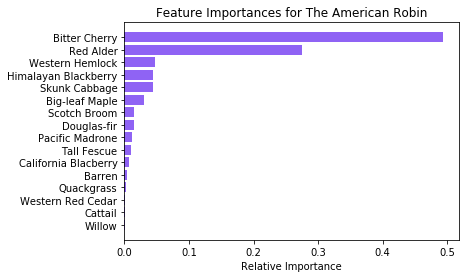

```python
features = X_train.columns.values
importances = rfr.feature_importances_
indices = np.argsort(importances)

plt.title('Feature Importances for The American Robin')
plt.barh(range(len(indices)), importances[indices], color='#8f63f4', align='center')
plt.yticks(range(len(indices)), features[indices])
plt.xlabel('Relative Importance')
plt.show()
```

## Now lets demonstrate how to generate predicted American Robin estimates based upon statistical weights stored in our baseline model

[figure not shown]

```python
predict = pd.merge(scene[['GRID_ID','Scenario','modified']],
                  data[['GRID_ID','Big-leaf Maple','Bitter Cherry','California Blacberry',
                        'Cattail','Douglas-fir','Himalayan Blackberry','Barren','Pacific Madrone',
                        'Quackgrass','Red Alder','Scotch Broom','Skunk Cabbage','Tall Fescue',
                        'Western Hemlock','Western Red Cedar','Willow']],
                  how='left', left_on='GRID_ID', right_on='GRID_ID')

predict.loc[predict['modified'] == 1, 'Big-leaf Maple'] = 0
predict.loc[predict['modified'] == 1, 'Bitter Cherry'] = 0
predict.loc[predict['modified'] == 1, 'California Blacberry'] = 0
predict.loc[predict['modified'] == 1, 'Cattail'] = 0
predict.loc[predict['modified'] == 1, 'Douglas-fir'] = 0
predict.loc[predict['modified'] == 1, 'Himalayan Blackberry'] = 0
predict.loc[predict['modified'] == 1, 'Barren'] = 1
predict.loc[predict['modified'] == 1, 'Pacific Madrone'] = 0
predict.loc[predict['modified'] == 1, 'Quackgrass'] = 0
predict.loc[predict['modified'] == 1, 'Red Alder'] = 0
predict.loc[predict['modified'] == 1, 'Scotch Broom'] = 0
predict.loc[predict['modified'] == 1, 'Skunk Cabbage'] = 0
predict.loc[predict['modified'] == 1, 'Tall Fescue'] = 0
predict.loc[predict['modified'] == 1, 'Western Hemlock'] = 0
predict.loc[predict['modified'] == 1, 'Western Red Cedar'] = 0
predict.loc[predict['modified'] == 1, 'Willow'] = 0

scenario1=predict.loc[(predict['Scenario'].isin([0,1]))&(predict['modified']==1)]
scenario2=predict.loc[(predict['Scenario'].isin([0,2]))&(predict['modified']==1)]
scenario3=predict.loc[(predict['Scenario'].isin([0,3]))&(predict['modified']==1)]
scenario4=predict.loc[(predict['Scenario'].isin([0,4]))&(predict['modified']==1)]
scenario5=predict.loc[(predict['Scenario'].isin([0,5]))&(predict['modified']==1)]

scenario1['pred_AmericanRobin'] = rfr.predict(scenario1[['Big-leaf Maple','Bitter Cherry','California Blacberry',
                        'Cattail','Douglas-fir','Himalayan Blackberry','Barren','Pacific Madrone',
                        'Quackgrass','Red Alder','Scotch Broom','Skunk Cabbage','Tall Fescue',
                        'Western Hemlock','Western Red Cedar','Willow']])
scenario2['pred_AmericanRobin'] = rfr.predict(scenario2[['Big-leaf Maple','Bitter Cherry','California Blacberry',
                        'Cattail','Douglas-fir','Himalayan Blackberry','Barren','Pacific Madrone',
                        'Quackgrass','Red Alder','Scotch Broom','Skunk Cabbage','Tall Fescue',
                        'Western Hemlock','Western Red Cedar','Willow']])
scenario3['pred_AmericanRobin'] = rfr.predict(scenario3[['Big-leaf Maple','Bitter Cherry','California Blacberry',
                        'Cattail','Douglas-fir','Himalayan Blackberry','Barren','Pacific Madrone',
                        'Quackgrass','Red Alder','Scotch Broom','Skunk Cabbage','Tall Fescue',
                        'Western Hemlock','Western Red Cedar','Willow']])
scenario4['pred_AmericanRobin'] = rfr.predict(scenario4[['Big-leaf Maple','Bitter Cherry','California Blacberry',
                        'Cattail','Douglas-fir','Himalayan Blackberry','Barren','Pacific Madrone',
                        'Quackgrass','Red Alder','Scotch Broom','Skunk Cabbage','Tall Fescue',
                        'Western Hemlock','Western Red Cedar','Willow']])
scenario5['pred_AmericanRobin'] = rfr.predict(scenario5[['Big-leaf Maple','Bitter Cherry','California Blacberry',
                        'Cattail','Douglas-fir','Himalayan Blackberry','Barren','Pacific Madrone',
                        'Quackgrass','Red Alder','Scotch Broom','Skunk Cabbage','Tall Fescue',
                        'Western Hemlock','Western Red Cedar','Willow']])
```